# **Practical Lab 3 - Univariate Linear Regression**

### *Univariate Linear Regression on the California Housing Prices Dataset*

## 🎯 **Goal**

This project aims to use simple linear regression models to understand how median house value is related to median income, population, and number of households. Analyzing each variable separately, we can determine which factor strongly correlates with median house value in the [California district dataset](https://www.kaggle.com/datasets/camnugent/california-housing-prices). The result of this analysis will help to gain insights into the socioeconomic factors that impact housing prices in the area.

Source of Data: [California Housing Prices](https://www.kaggle.com/datasets/camnugent/california-housing-prices)

- Importing libraries and modules

```python
from sklearn import linear_model
from sklearn.metrics import mean_absolute_error, mean_squared_error
import pandas as pd
import matplotlib.pyplot as plt
import seaborn as sns
sns.set_theme(style='whitegrid')
```

- Loading data from housing.csv file into pandas' data-frame.

```python
df_house = pd.read_csv("./datasets/housing.csv")
df_house.head()
```

|  | longitude | latitude | housing_median_age | total_rooms | total_bedrooms | population | households | median_income | median_house_value | ocean_proximity |
| --- | --- | --- | --- | --- | --- | --- | --- | --- | --- | --- |
| 0 | -122.23 | 37.88 | 41.0 | 880.0 | 129.0 | 322.0 | 126.0 | 8.3252 | 452600.0 | NEAR BAY |
| 1 | -122.22 | 37.86 | 21.0 | 7099.0 | 1106.0 | 2401.0 | 1138.0 | 8.3014 | 358500.0 | NEAR BAY |
| 2 | -122.24 | 37.85 | 52.0 | 1467.0 | 190.0 | 496.0 | 177.0 | 7.2574 | 352100.0 | NEAR BAY |
| 3 | -122.25 | 37.85 | 52.0 | 1274.0 | 235.0 | 558.0 | 219.0 | 5.6431 | 341300.0 | NEAR BAY |
| 4 | -122.25 | 37.85 | 52.0 | 1627.0 | 280.0 | 565.0 | 259.0 | 3.8462 | 342200.0 | NEAR BAY |

- Creating a new DataFrame called `df_test` by randomly sampling 30% of the rows from the `df_house` for the test purpose.

```python
df_test = df_house.sample(frac=0.3, random_state=300)
df_test.reset_index().head()
```

|  | index | longitude | latitude | housing_median_age | total_rooms | total_bedrooms | population | households | median_income | median_house_value | ocean_proximity |
| --- | --- | --- | --- | --- | --- | --- | --- | --- | --- | --- | --- |
| 0 | 10385 | -117.65 | 33.60 | 15.0 | 5736.0 | NaN | 2529.0 | 762.0 | 6.4114 | 278700.0 | <1H OCEAN |
| 1 | 3031 | -119.42 | 35.40 | 24.0 | 2585.0 | 480.0 | 1442.0 | 424.0 | 2.8452 | 104700.0 | INLAND |
| 2 | 10454 | -117.66 | 33.48 | 22.0 | 809.0 | 180.0 | 334.0 | 157.0 | 2.3846 | 500001.0 | <1H OCEAN |
| 3 | 15989 | -122.47 | 37.76 | 39.0 | 3200.0 | 689.0 | 1391.0 | 618.0 | 3.6346 | 338000.0 | NEAR BAY |
| 4 | 2391 | -119.33 | 36.89 | 15.0 | 1879.0 | 411.0 | 755.0 | 294.0 | 2.0000 | 83300.0 | INLAND |

## 📊 **Statistics of DataFrame**

- Describing statistics of a DataFrame(df_house). Statistical data includes count, mean, standard deviation, minimum, maximum and quartiles.

```python
df_house.describe()
```

|  | longitude | latitude | housing_median_age | total_rooms | total_bedrooms | population | households | median_income | median_house_value |
| --- | --- | --- | --- | --- | --- | --- | --- | --- | --- |
| count | 20640.000000 | 20640.000000 | 20640.000000 | 20640.000000 | 20433.000000 | 20640.000000 | 20640.000000 | 20640.000000 | 20640.000000 |
| mean | -119.569704 | 35.631861 | 28.639486 | 2635.763081 | 537.870553 | 1425.476744 | 499.539680 | 3.870671 | 206855.816909 |
| std | 2.003532 | 2.135952 | 12.585558 | 2181.615252 | 421.385070 | 1132.462122 | 382.329753 | 1.899822 | 115395.615874 |
| min | -124.350000 | 32.540000 | 1.000000 | 2.000000 | 1.000000 | 3.000000 | 1.000000 | 0.499900 | 14999.000000 |
| 25% | -121.800000 | 33.930000 | 18.000000 | 1447.750000 | 296.000000 | 787.000000 | 280.000000 | 2.563400 | 119600.000000 |
| 50% | -118.490000 | 34.260000 | 29.000000 | 2127.000000 | 435.000000 | 1166.000000 | 409.000000 | 3.534800 | 179700.000000 |
| 75% | -118.010000 | 37.710000 | 37.000000 | 3148.000000 | 647.000000 | 1725.000000 | 605.000000 | 4.743250 | 264725.000000 |
| max | -114.310000 | 41.950000 | 52.000000 | 39320.000000 | 6445.000000 | 35682.000000 | 6082.000000 | 15.000100 | 500001.000000 |

- There are missing values in the "total_bedrooms" column, as indicated by the count discrepancy between it and the other columns.
- Variables such as "population", "households" ,"median_income" and "median_house_value" are critical indicators for assessing socio-economic status and housing market trends.
- Creating derived features, such as "rooms per household" or "bedrooms per room," could offer additional insights into housing characteristics and occupancy patterns.

## 1. 📉 **Median house value Vs. Median income**

This linear regression model aims to understand how changes in household income influence housing prices. Through this model, we seek to establish a quantitative relationship between these two variables, enabling us to predict house values based on income levels.

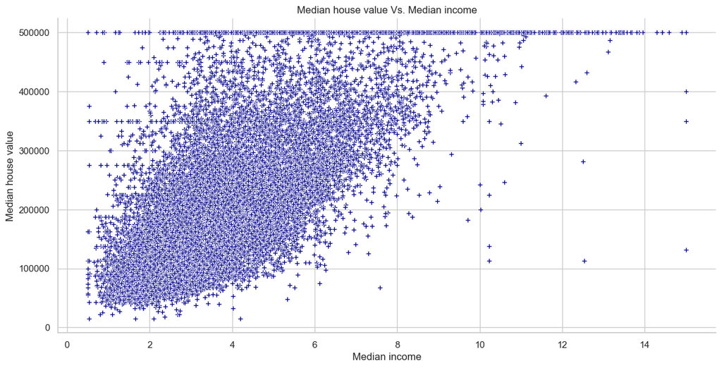

```python
graph = sns.relplot(data=df_house[["median_house_value", "median_income"]], x="median_income", y="median_house_value", marker="P", aspect=2, height=6, color="darkblue")
plt.ylabel("Median house value")
plt.xlabel("Median income")
plt.title("Median house value Vs. Median income")
```

### ✅ **Prediction based on Median income**

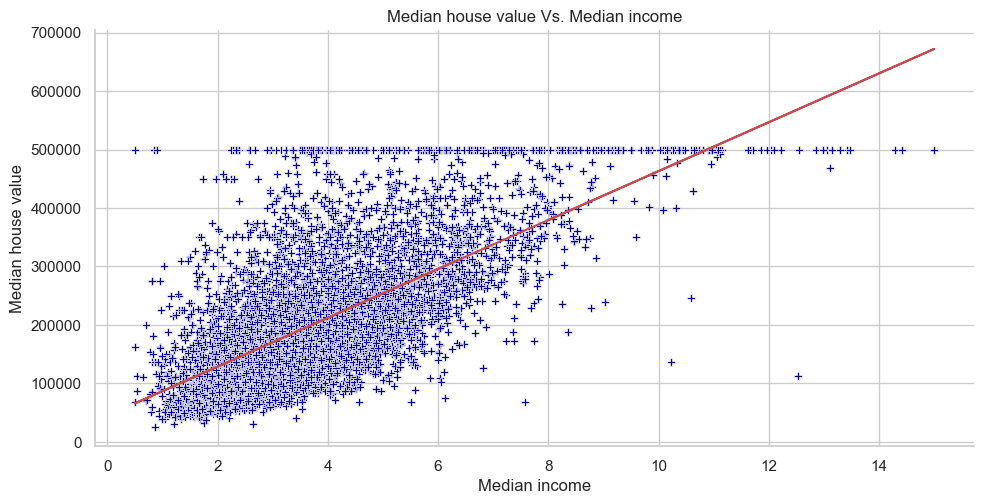

```python
sns.relplot(data=df_test[["median_house_value", "median_income"]], x="median_income", y="median_house_value", marker="P", aspect=2, color="darkblue")
plt.ylabel("Median house value")
plt.xlabel("Median income")
plt.title("Median house value Vs. Median income")

# performing linear regression on the data.
reg = linear_model.LinearRegression()
reg.fit(X=df_house[ ['median_income']],y=df_house['median_house_value'])
y_median_house_value = reg.predict(df_test[ ['median_income']])

# plotting a resulting line on the existing scatter plot.
plt.plot(df_test[ ['median_income']],y_median_house_value, c="r")
```

### Intercept, slop, Mean squared error and Mean absolute error for Median house value vs. Median income

```python
print(f'Interceptor: {reg.intercept_}\nSlope:  {reg.coef_}\nMean Absolute Error: {mean_absolute_error(df_test[["median_house_value"]],y_median_house_value)}\nMean Squred Error: {mean_squared_error(df_test[["median_house_value"]],y_median_house_value)}')
```

```
Interceptor: 45085.5767032679
Slope:  [41793.8492019]
Mean Absolute Error: 63187.69319545478
Mean Squred Error: 7098448259.898343
```

## 2. 📉 **Median house value Vs. Population**

This model aims to examine the relationship between population dynamics and housing prices. This analysis seeks to quantify how variations in population size influence median house values within a given area.

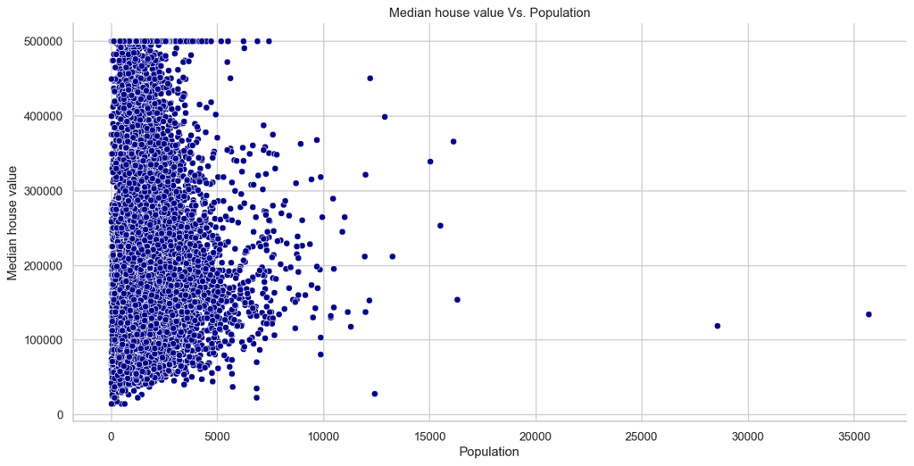

```python
sns.relplot(data=df_house, x="population", y="median_house_value", aspect=2, height=6,color="darkblue")
plt.ylabel("Median house value")
plt.xlabel("Population")
plt.title("Median house value Vs. Population")
```

### ✅ **Prediction based on Population**

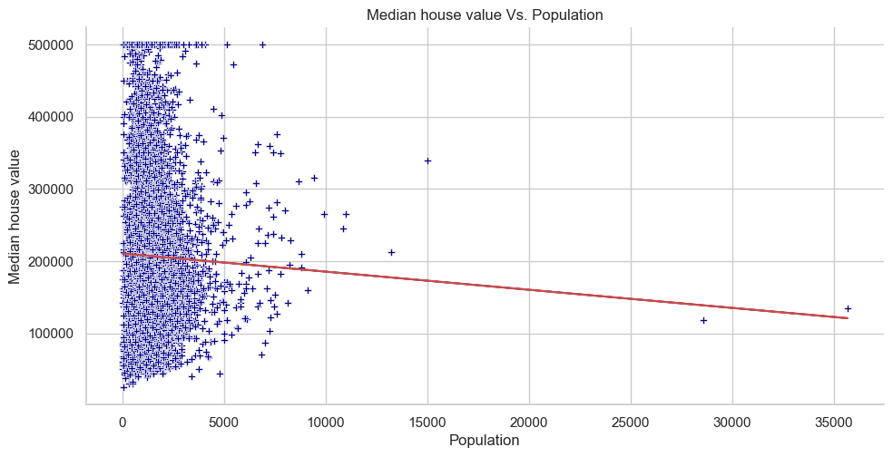

```python
sns.relplot(data=df_test[["median_house_value", "population"]], x="population", y="median_house_value", marker="P", aspect=2, color="darkblue")
plt.ylabel("Median house value")
plt.xlabel("Population")
plt.title("Median house value Vs. Population")

# performing linear regression on the data.
reg = linear_model.LinearRegression()
reg.fit(X=df_house[ ['population']],y=df_house['median_house_value'])
y_median_house_value = reg.predict(df_test[ ['population']])

# plotting a resulting line on the existing scatter plot.
plt.plot(df_test[ ['population']],y_median_house_value, c="r")
```

### Intercept, slop, Mean squared error and Mean absolute error for Median house value vs. Population

```python
print(f'Interceptor: {reg.intercept_}\nSlope:  {reg.coef_}\nMean Absolute Error: {mean_absolute_error(df_test[["median_house_value"]],y_median_house_value)}\nMean Squred Error: {mean_squared_error(df_test[["median_house_value"]],y_median_house_value)}')
```

```
Interceptor: 210436.26207627333
Slope:  [-2.51175277]
Mean Absolute Error: 91240.72757549585
Mean Squred Error: 13246573845.437338
```

## 3. 📉 **Median house value Vs. Households**

The objective is to determine the impact of housing occupancy on property prices. This model endeavours to quantify the relationship between these variables, facilitating predictions of house values based on household counts.

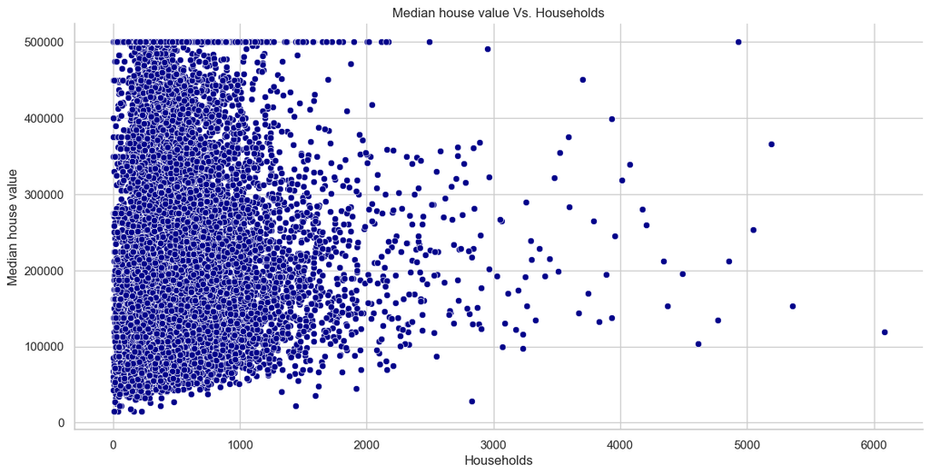

```python
sns.relplot(data=df_house, x="households", y="median_house_value", aspect=2, height=6, color="darkblue")
plt.ylabel("Median house value")
plt.xlabel("Households")
plt.title("Median house value Vs. Households")
```

### ✅ **Prediction based on Households**

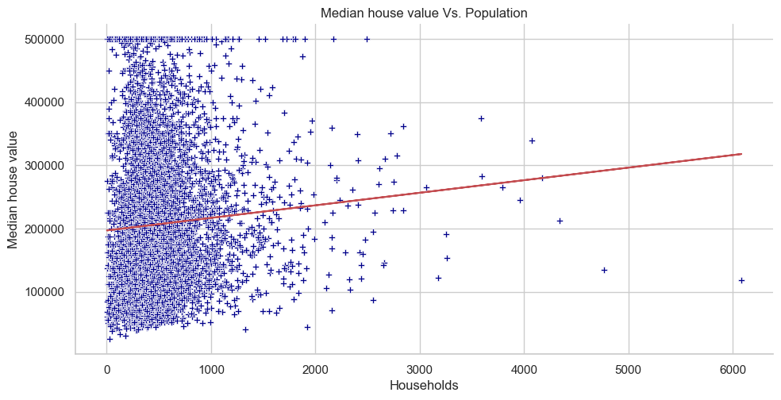

```python
sns.relplot(data=df_test[["median_house_value", "households"]], x="households", y="median_house_value", marker="P", aspect=2, color="darkblue")
plt.ylabel("Median house value")
plt.xlabel("Households")
plt.title("Median house value Vs. Population")

# performing linear regression on the data.
reg = linear_model.LinearRegression()
reg.fit(X=df_house[ ['households']],y=df_house['median_house_value'])
y_median_house_value = reg.predict(df_test[ ['households']])

# plotting a resulting line on the existing scatter plot.
plt.plot(df_test[ ['households']],y_median_house_value, c="r")
```

### Intercept, slop, Mean squared error and Mean absolute error for Median house value vs. Households

```python
print(f'Interceptor: {reg.intercept_}\nSlope:  {reg.coef_}\nMean Absolute Error: {mean_absolute_error(df_test[["median_house_value"]],y_median_house_value)}\nMean Squred Error: {mean_squared_error(df_test[["median_house_value"]],y_median_house_value)}')
```

```
Interceptor: 196928.57716233088
Slope:  [19.87277516]
Mean Absolute Error: 90812.344679286
Mean Squred Error: 13196053080.50271
```

# **Summary of intercept, slop and errors**

| Type | Intercept | Slop | Mean Absolute Error | Mean Squared Error |
| --- | --- | --- | --- | --- |
| Vs. Mean Income | 45085.5767032679 | 41793.8492019 | 63187.69319545478 | 7098448259.898343 |
| Vs. Households | 196928.57716233088 | 19.87277516 | 90812.344679286 | 13196053080.50271 |
| Vs. Population | 210436.26207627333 | -2.51175277 | 91240.72757549585 | 13246573845.437338 |

## **Conclusion and final insights**

The models analyzed how different factors relate to house prices. The one focusing on income found a moderate link between higher incomes and higher house values. However, models examining households and population didn't show strong connections to house prices. Overall, while these models give some insights, they aren't perfect at predicting actual house values, suggesting they might need more factors to make better predictions.

# ➕ **Additional**

## 📊 **Median House Value Vs. Median Income Vs. Population Vs. Housholds**

In this expanded linear regression model predicting Median House Value based on Median Income, Population, and Households, we aim to explore the multifaceted influences on housing prices. Through this model, we endeavour to uncover the collective impact of income levels, community size, and household composition on housing market dynamics.

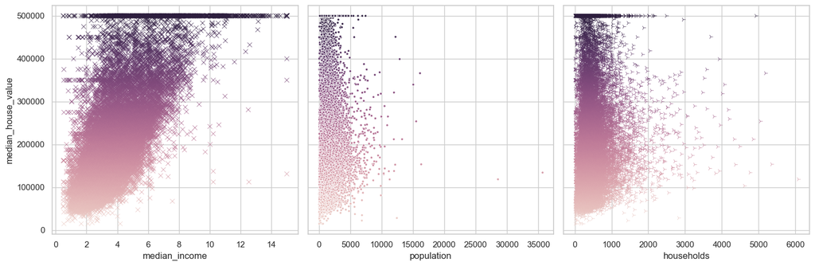

```python
f, ax = plt.subplots(1, 3, figsize=(15, 5), gridspec_kw=dict(width_ratios=[5,5,5]), sharey=True)
sns.scatterplot(data=df_house, x="median_income",y="median_house_value",marker="x", hue="median_house_value", ax=ax[0], legend=False)
sns.scatterplot(data=df_house, x="population",y="median_house_value", marker=".", hue="median_house_value",ax=ax[1], legend=False)
sns.scatterplot(data=df_house, x="households",y="median_house_value", marker="4",hue="median_house_value", ax=ax[2], legend=False)
f.tight_layout()
```

### ✅ **Collective house value prediction based on Income, Population and Households**

```python
reg = linear_model.LinearRegression()
reg.fit(df_house[["median_income", "population", "households"]], df_house["median_house_value"])
X = df_test[["median_income", "population", "households"]]
X.reset_index(drop= True, inplace=True)
y_output = pd.DataFrame(reg.predict(df_test[["median_income", "population", "households"]]),columns=['Predicted House Value'])
y_output.reset_index(drop=True, inplace=True)
df_predicted = pd.concat([X, y_output['Predicted House Value']],axis="columns")
df_predicted.head(10)
```

|  | median_income | population | households | Predicted House Value |
| --- | --- | --- | --- | --- |
| 0 | 6.4114 | 2529.0 | 762.0 | 298697.124178 |
| 1 | 2.8452 | 1442.0 | 424.0 | 152879.210129 |
| 2 | 2.3846 | 334.0 | 157.0 | 147051.502982 |
| 3 | 3.6346 | 1391.0 | 618.0 | 215252.903705 |
| 4 | 2.0000 | 755.0 | 294.0 | 130999.406914 |
| 5 | 3.1484 | 722.0 | 358.0 | 189220.233268 |
| 6 | 5.2888 | 1316.0 | 538.0 | 276206.866067 |
| 7 | 4.4875 | 1494.0 | 619.0 | 246116.426779 |
| 8 | 2.5603 | 2122.0 | 850.0 | 169662.444423 |
| 9 | 4.1375 | 1750.0 | 523.0 | 206361.531566 |

## **Geo-Housing: Latitude, Longitude, and Ocean Proximity Impact on Property Values**

This model aims to understand how geographic and environmental factors influence housing prices. By incorporating latitude and longitude coordinates, we aim to capture spatial variations in property values, while 'ocean_proximity' is a proxy for environmental amenities or risks.

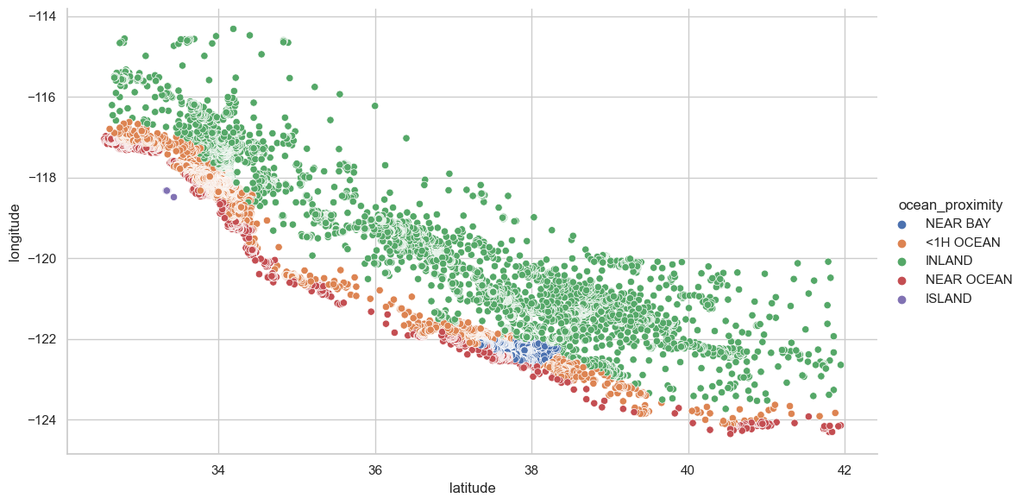

```python
df_filtered = df_house[['latitude', 'longitude', 'ocean_proximity']]
g = sns.relplot(data=df_filtered, x="latitude", y="longitude", hue="ocean_proximity" ,aspect=1.75, height=6)
```

Training the model

```python
reg = linear_model.LinearRegression()
reg.fit(df_house[['latitude','longitude']],df_house['median_house_value'])

X = df_house[['latitude','longitude']]
X.reset_index(drop=True, inplace=True)
y = pd.DataFrame(reg.predict(X),columns=["Approx. Value"])

pd.concat([X,y],axis="columns").head(10)
```

|  | latitude | longitude | Approx. Value |
| --- | --- | --- | --- |
| 0 | 37.88 | -122.23 | 239933.576458 |
| 1 | 37.86 | -122.22 | 240612.502077 |
| 2 | 37.85 | -122.24 | 242732.199116 |
| 3 | 37.85 | -122.25 | 243444.292808 |
| 4 | 37.85 | -122.25 | 243444.292808 |
| 5 | 37.85 | -122.25 | 243444.292808 |
| 6 | 37.84 | -122.25 | 244139.802463 |
| 7 | 37.84 | -122.25 | 244139.802463 |
| 8 | 37.84 | -122.26 | 244851.896155 |
| 9 | 37.84 | -122.25 | 244139.802463 |